title: “t5phage_ecoli_bioinformatics” author: “Jigyasa_Arora and Sasha Mikheyev” date: “7/5/2020” output: html_document

#install and load the R packages-

```r
#NOTE: If you cannot install softwares viaBiocManaager, try this option #https://community.rstudio.com/t/install-packages-unable-to-access-index-for-repository-try-disabling-secure-download-method-for-http/16578

#install.packages("BiocManager")
library(BiocManager)
#BiocManager::install("Rbowtie2")
#BiocManager::install("Rsamtools")
#BiocManager::install("BBCAnalyzer")
library(Rbowtie2)
library(Rsamtools)
library(BBCAnalyzer)
#install.packages("dplyr")
library(dplyr)
#source("https://bioconductor.org/biocLite.R")
#biocLite("VariantTools")
library(VariantTools)
#devtools::install_github(repo="knausb/vcfR")
library(vcfR)
#install.packages("ape")
library(ape)
```

Step1: Visualize the read quality via fastQC Download link-https://www.bioinformatics.babraham.ac.uk/projects/download.html Check the output file-“mutant1_OIST-2015-03-28_fastqc.html”

Step2: Generate an index for the reference genome- We will be using “gi|254160123|ref|NC_012967.1| Escherichia coli B str. REL606” as the reference.

```r
td<-"../working_data"
refs <- dir("../working_data", "sequence.fasta",full.names =TRUE)[1]
(cmdout<-bowtie2_build(references = refs,bt2Index=file.path(td, "sequence"), "--threads 4 --quiet",overwrite=TRUE))
```

```
## character(0)
```

Step3: Map the mutant E.coli reads to the reference genome. This generates a sam file. #ref-https://www.bioconductor.org/packages/devel/bioc/vignettes/Rbowtie2/inst/doc/Rbowtie2-Introduction.html

```r
reads_1 <- dir("../working_data", "mutant1_OIST-2015-03-28.fq",full.names =TRUE)
cmdout2<-bowtie2(bt2Index = file.path(td, "sequence"),samOutput = file.path(td, "mutant1.sam"),seq1 = reads_1,overwrite = TRUE)
```

```r
head(readLines(file.path(td, "mutant1.sam"))) #examine how the sam file looks like.
```

```
## [1] "@HD\tVN:1.0\tSO:unsorted"
## [2] "@SQ\tSN:gi|254160123|ref|NC_012967.1|\tLN:4629812"
## [3] "@PG\tID:bowtie2\tPN:bowtie2\tVN:2.3.2\tCL:\"C:\\Users\\JIGYAS~1.OIS\\DOCUME~1\\R\\WIN-LI~1\\3.6\\Rbowtie2\\BOWTIE~1.EXE -x ../working_data/sequence -U ../working_data/mutant1_OIST-2015-03-28.fq -S ../working_data/mutant1.sam\""
## [4] "M00923:134:000000000-A5ELA:1:2109:24002:5853\t16\tgi|254160123|ref|NC_012967.1|\t2\t24\t4M3I144M\t*\t0\t0\tTCAGCTTTTCATTCTGACTGCAACGGGCAATATGTCTCTGTGTGGATTAAAAAAAGAGTGTCTGATAGCAGCTTCTGAACTGGTTACCTGCCGTGAGTAAATTAAAATTTTATTGACTTAGGTCACTAAATACTTTAACCAATATAGGCAT\tFGGGGGGGGFFDGGGGGGGGGGGGGGGFGGCG…
## [5] "M00923:134:000000000-A5ELA:1:2110:26800:16309\t16\tgi|254160123|ref|NC_012967.1|\t2\t24\t2M6I143M\t*\t0\t0\tTATTCAGCTTTTCATTCTGACTGCAACGGGCAATATGTCTCGGTGTGGATTAAAAAAAGAGTGTCTGATAGCAGCTTCTGAACTGGTTACCTGCCGTGAGTAAATTAAAATTTTATTGACTTAGGTCACTAAATACTTTAACCAATATAGG\t4,=4=E@,,,4,,=,F;GFC,4@+?@,BE:,…
## [6] "M00923:134:000000000-A5ELA:1:2113:14667:7921\t16\tgi|254160123|ref|NC_012967.1|\t2\t0\t1M19I99M\t*\t0\t0\tCCTTAGTAAGTATTTTTCAGCTTTTCATTCTGACTGCAACGGGCAATATGTCTCTGTGTGGATTAAAAAAAGAGTGTCTGATAGCAGCTTCTGAACTGGTTACCTGCCGTGAGTAAATT\tFFGGGGFGFGGGGGGGGGGGGGGGGGGGGGGGGGGGGGGGGGGGGGGGGGGGFGGDEDGGGGGGG…
```

Step4:Create a Bam file from Sam file.

```r
sam_1 <- dir("../working_data", "mutant1.sam",full.names =TRUE)
asBam(sam_1, destination=sub("\\.sam(\\.gz)?", "", sam_1),overwrite=TRUE) #.bam extension is automatically added to the output.
```

```
## [1] "../working_data/mutant1.bam"
```

Question: Why is Step4 important? Hint: compare the size of Sam file with Bam file

Step5:Sort the Bam file according to reference genome’s chromosomal position.

```r
bam_1<-dir("../working_data", "mutant1.bam",full.names =TRUE)[1]
#sorted_bam_1<-dir("../working_data", "sorted_mutant1.bam",full.names =TRUE)

sorted <- sortBam(bam_1, destination=sub("mutant1.bam","sorted_mutant1",bam_1),overwrite=TRUE)

#index the sorted bam file-
indexBam(sorted)
```

```
##       ../working_data/sorted_mutant1.bam
## "../working_data/sorted_mutant1.bam.bai"
```

Step6:Variant Calling- generated using “Freebayes” software. This step was performed locally. Visualize the variant calling file (.vcf file) and filter it. https://knausb.github.io/vcfR_documentation/filtering_data.html

```r
#visualize the VCF file-
vcf_file <- dir("../working_data", "sorted_mutant1.vcf",full.names = TRUE)[2]
dna_file <- dir("../working_data/", "sequence.fasta", full.names = TRUE)[1]
gff_file <- dir("../raw_data/", "annotation.sorted.gff3", full.names = TRUE)

vcf <- read.vcfR(vcf_file, verbose = FALSE)
dna <- ape::read.dna(dna_file, format = "fasta")
gff <- read.table(gff_file, sep="\t", quote="")

chrom <- create.chromR(name="Supercontig", vcf=vcf, seq=dna, ann=gff, verbose=FALSE)
chrom <- proc.chromR(chrom, verbose = TRUE)
```

```
## Nucleotide regions complete.
```

```
##   elapsed time:  2.03
```

```
## N regions complete.
```

```
##   elapsed time:  2.11
```

```
## Population summary complete.
```

```
##   elapsed time:  0.03
```

```
## window_init complete.
```

```
##   elapsed time:  0
```

```
## windowize_fasta complete.
```

```
##   elapsed time:  1.4
```

```
## windowize_annotations complete.
```

```
##   elapsed time:  0.44
```

```
## windowize_variants complete.
```

```
##   elapsed time:  0
```

```r
head(chrom)
```

```
## *****   Class chromR, method head   *****
## Name:  Supercontig
## Length:  4,629,812
##
## *****     Sample names (chromR)     *****
## [1] "unknown"
##
## *****    VCF fixed data (chromR)    *****
##      CHROM                           POS     ID REF    ALT    QUAL
## [1,] "gi|254160123|ref|NC_012967.1|" "1957"  NA "TGAA" "CAAG" "8.98959e-10"
## [2,] "gi|254160123|ref|NC_012967.1|" "4652"  NA "A"    "T"    "0"
## [3,] "gi|254160123|ref|NC_012967.1|" "8283"  NA "C"    "A"    "3.13406e-15"
## [4,] "gi|254160123|ref|NC_012967.1|" "12596" NA "T"    "G"    "0"
## [5,] "gi|254160123|ref|NC_012967.1|" "21449" NA "C"    "A"    "1.507e-15"
## [6,] "gi|254160123|ref|NC_012967.1|" "23357" NA "T"    "A"    "0.261035"
##      FILTER
## [1,] NA
## [2,] NA
## [3,] NA
## [4,] NA
## [5,] NA
## [6,] NA
## [1] "..."
##         CHROM                           POS       ID REF ALT QUAL      FILTER
## [1797,] "gi|254160123|ref|NC_012967.1|" "4617309" NA "T" "C" "0"       NA
## [1798,] "gi|254160123|ref|NC_012967.1|" "4620011" NA "C" "T" "0"       NA
## [1799,] "gi|254160123|ref|NC_012967.1|" "4625479" NA "C" "A" "0"       NA
## [1800,] "gi|254160123|ref|NC_012967.1|" "4626907" NA "A" "G" "287.02"  NA
## [1801,] "gi|254160123|ref|NC_012967.1|" "4628436" NA "T" "C" "593.016" NA
## [1802,] "gi|254160123|ref|NC_012967.1|" "4629590" NA "G" "A" "0"       NA
##
## INFO column has been suppressed, first INFO record:
##  [1] "AB=0"         "ABP=0"        "AC=0"         "AF=0"         "AN=1"
##  [6] "AO=2"         "CIGAR=2X1M1X" "DP=7"         "DPB=7"        "DPRA=0"
## [11] "EPP=7.35324"  "EPPR=3.44459" "GTI=0"        "LEN=4"        "MEANALT=1"
## [16] "MQM=42"       "MQMR=42"      "NS=1"         "NUMALT=1"     "ODDS=22.2984"
## [21] "PAIRED=0"     "PAIREDR=0"    "PAO=0"        "PQA=0"        "PQR=0"
## [26] "PRO=0"        "QA=62"        "QR=173"       "RO=5"         "RPL=0"
## [31] "RPP=7.35324"  "RPPR=3.44459" "RPR=2"        "RUN=1"        "SAF=0"
## [36] "SAP=7.35324"  "SAR=2"        "SRF=4"        "SRP=6.91895"  "SRR=1"
```

[output cut: 10 more lines]

```
##
## *****      Var info (chromR)       *****
## *****       First 6 columns        *****
##                           CHROM   POS MQ DP mask n
## 1 gi|254160123|ref|NC_012967.1|  1957 NA  7 TRUE 1
## 2 gi|254160123|ref|NC_012967.1|  4652 NA 15 TRUE 1
## 3 gi|254160123|ref|NC_012967.1|  8283 NA 14 TRUE 1
## 4 gi|254160123|ref|NC_012967.1| 12596 NA 11 TRUE 1
## 5 gi|254160123|ref|NC_012967.1| 21449 NA  9 TRUE 1
## 6 gi|254160123|ref|NC_012967.1| 23357 NA 12 TRUE 1
##
## *****      VCF mask (chromR)        *****
## Percent unmasked: 100
##
## *****      End head (chromR)        *****
```

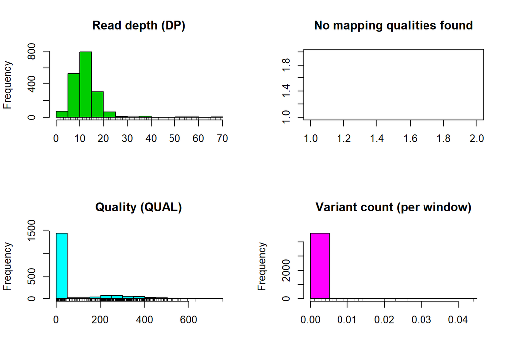

```r
plot(chrom) #plots the quality scores
```

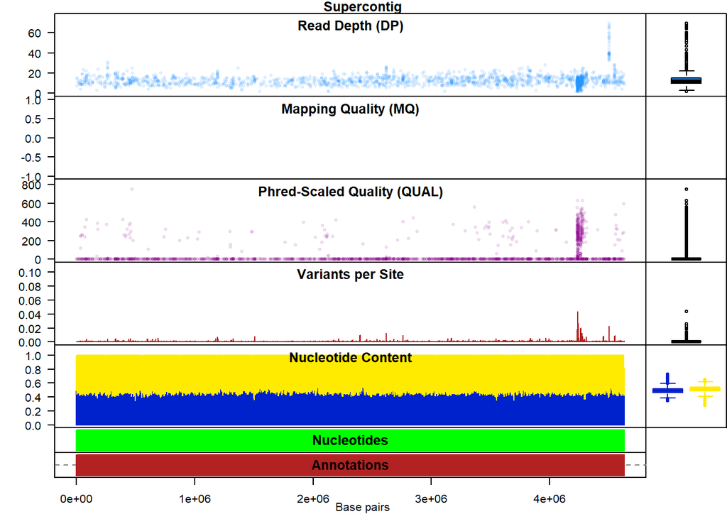

```r
chromoqc(chrom, dp.alpha = 22) #plots the mapped variants on the reference genome.
```

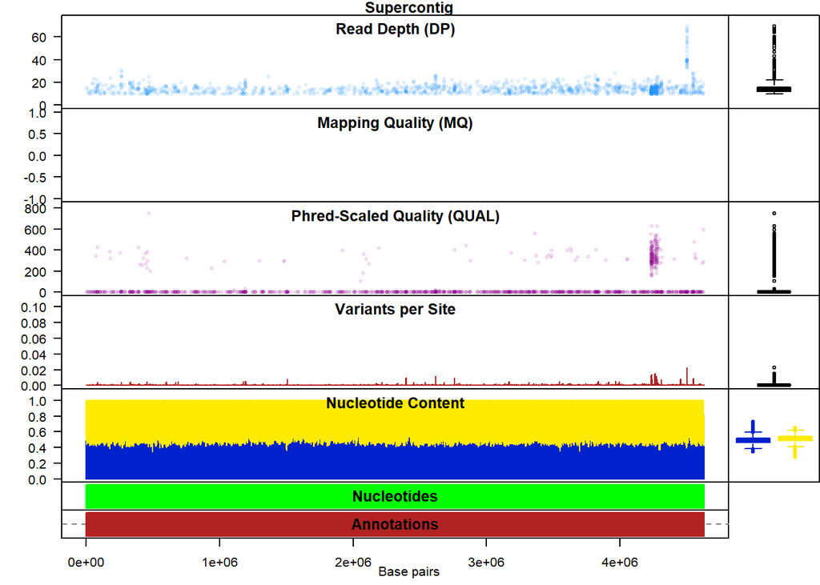

```r
#filter the variants-
chrom <- masker(chrom, min_QUAL=0, min_DP=10, max_DP=800, min_MQ=0)
chrom <- proc.chromR(chrom, verbose = FALSE)
chromoqc(chrom, dp.alpha = 22) #plots the mapped variants on the reference genome.
```

```r
write.vcf(chrom, file="../working_data/filtered_sorted_mutant1.vcf.gz",mask = TRUE)
```

###Question: Repeat all the above steps with the remaining E.coli mutant and wild-type reads. Q1/Are the mutation profile similar for all the mutants? Q2/What is the difference between the mutants and wild-type sample? Is the wild-type more similar to the reference genome?